# ICE Arrests: Illinois Since January 1, 2026

Detention itineraries, transfer flows, and removal outcomes

Published

October 14, 2026

This report traces ICE arrests made in **Illinois** on or after **January 1, 2026** through the full detention and removal pipeline, using individual-level FOIA data from the [Deportation Data Project](https://deportationdata.org).

**626** arrests · **620** distinct individuals · **496** detention stays · **36.1%** ultimately removed

## Overview

### Monthly arrest volume

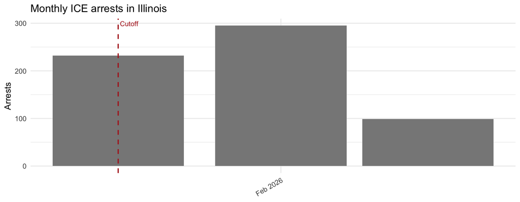

### Who was arrested

**Top nationalities**

| Country | N | % |
| --- | --- | --- |
| MEXICO | 151 | 24.1 |
| VENEZUELA | 121 | 19.3 |
| COLOMBIA | 84 | 13.4 |
| ECUADOR | 61 | 9.7 |
| NICARAGUA | 32 | 5.1 |
| GUATEMALA | 21 | 3.4 |
| HONDURAS | 19 | 3.0 |
| PERU | 19 | 3.0 |
| CHINA, PEOPLES REPUBLIC OF | 18 | 2.9 |
| INDIA | 15 | 2.4 |
| RUSSIA | 12 | 1.9 |
| EL SALVADOR | 8 | 1.3 |
| KYRGYZSTAN | 7 | 1.1 |
| CUBA | 6 | 1.0 |
| HAITI | 5 | 0.8 |

**Arrest type**

| Arrest type | N | % |
| --- | --- | --- |
| Targeted | 570 | 91.1 |
| Collateral | 56 | 8.9 |

**Criminality at arrest**

| Criminality | N | % |
| --- | --- | --- |
| 3 Other Immigration Violator | 383 | 61.2 |
| 1 Convicted Criminal | 151 | 24.1 |
| 2 Pending Criminal Charges | 92 | 14.7 |

## Arrest Locations in Illinois

County-level map based on `apprehension_site_landmark`. Landmarks naming a county in the state, or a place with a known county (prisons, field offices, airports), are mapped. Field-office-wide landmarks (e.g. “CHI GENERAL AREA, NON-SPECIFIC”) cover several states and can’t be placed in a county; they are summarized alongside the map.

[interactive chart not shown]

Share of arrests shown on the map

| Arrest location | N | % of arrests |
| --- | --- | --- |
| Mapped to a county | 83 | 13.3 |
| Field office area, non-specific | 477 | 76.2 |
| Fugitive operations, no county | 60 | 9.6 |
| Other / unresolved | 4 | 0.6 |
| Located in another state | 1 | 0.2 |
| Missing landmark | 1 | 0.2 |

Largest unmapped landmarks

| Unmapped landmark | N | % |
| --- | --- | --- |
| Chi General Area, Non-Specific | 423 | 67.6 |
| Chifugitive Operations | 59 | 9.4 |
| Stl General Non-Specific | 43 | 6.9 |
| Rii General Area, Non-Specific | 9 | 1.4 |
| St Louis Ice Office | 3 | 0.5 |
| Bsa General Area, Non-Specific | 2 | 0.3 |
| B - Lafayette County Jail | 1 | 0.2 |
| Fugitive Operations Il State | 1 | 0.2 |

> **Coverage:** 13% of arrests mapped to a county. The map shows only these arrests; the tables at right show what is left out.

## Detention Facility Maps and Transfer Flows

**Blue dots** = first detention facility. **Orange dots** = last detention facility. **Grey lines** = transfer flows between facilities; line width is proportional to the log of the number of transfers on that route. Only flows with ≥ 5 transfers are shown.

[interactive chart not shown]

**First detention facility (top 8):**

| DETLOC | Facility | City | State | N | % |
| --- | --- | --- | --- | --- | --- |
| BSAHOLD | Broadview Service Staging | Broadview | IL | 283 | 57.1 |
| CHIHOLD | Chicago Field Office | Chicago | IL | 98 | 19.8 |
| RIIHOLD | Rock Island Hold Room | Rock Island | IL | 56 | 11.3 |
| STLHOLD | St. Louis Holdroom | St. Louis | MO | 56 | 11.3 |
| FULCJIN | Fulton County Jail Indiana | Rochester | IN | 2 | 0.4 |
| INMIAMI | Miami Correctional Center | Bunker Hill | IN | 1 | 0.2 |

**Last detention facility (top 10):**

| DETLOC | Facility | City | State | N | % |
| --- | --- | --- | --- | --- | --- |
| CLAYCIN | Clay County Justice Center | Brazil | IN | 49 | 9.9 |
| GREENMO | Greene County Jail | Springfield | MO | 31 | 6.2 |
| HPKNSKY | Hopkins County Jail | Madisonville | KY | 30 | 6.0 |
| PINEPLA | Pine Prairie ICE Processing Center | Pine Prairie | LA | 30 | 6.0 |
| JENADLA | Central Louisiana ICE Processing Center (CLIPC) | Jena | LA | 23 | 4.6 |
| INMIAMI | Miami Correctional Center | Bunker Hill | IN | 22 | 4.4 |
| JKPCCLA | Jackson Parish Correctional Center | Jonesboro | LA | 20 | 4.0 |
| CPBDCKY | Campbell County Detention Center | Newport | KY | 19 | 3.8 |
| JENATLA | Alexandria Staging Facility | Alexandria | LA | 19 | 3.8 |
| STGENMO | Ste. Genevieve County Sheriff/Jail | Ste. Genevieve | MO | 18 | 3.6 |

## Removal Pipeline Flow

Each band traces one group through the pipeline: **Illinois arrest → first facility → last facility → outcome.** Band width is proportional to number of stays.

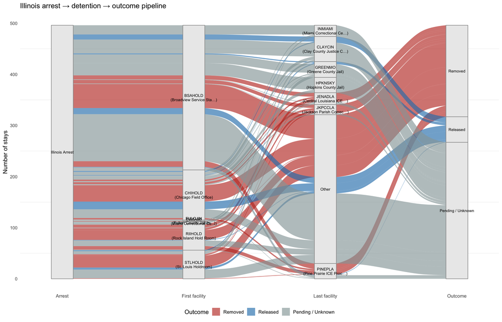

**Final outcomes:**

| Release reason | N | % |
| --- | --- | --- |
| NA | 267 | 53.8 |
| Removed | 179 | 36.1 |
| Bonded Out - IJ | 14 | 2.8 |
| Voluntary departure | 13 | 2.6 |
| Order of recognizance | 9 | 1.8 |
| Transferred | 5 | 1.0 |
| U.S. Marshals or other agency (explain in Detention Comments) | 4 | 0.8 |
| Order of supervision | 2 | 0.4 |
| Court Ordered | 1 | 0.2 |
| Paroled | 1 | 0.2 |
| Proceedings Terminated | 1 | 0.2 |

**All facilities in itineraries (top 15):**

| DETLOC | Appearances | % of stays |
| --- | --- | --- |
| BSAHOLD | 422 | 85.1 |
| CLAYCIN | 343 | 69.2 |
| INPHOLD | 194 | 39.1 |
| CHIHOLD | 101 | 20.4 |
| GREENMO | 67 | 13.5 |
| SCOTTIA | 63 | 12.7 |
| STLHOLD | 61 | 12.3 |
| RIIHOLD | 56 | 11.3 |
| STGENMO | 52 | 10.5 |
| PINEPLA | 46 | 9.3 |
| INMIAMI | 42 | 8.5 |
| CLINTIN | 41 | 8.3 |
| DODGEWI | 38 | 7.7 |
| JENATLA | 34 | 6.9 |
| HPKNSKY | 32 | 6.5 |

## Removal Destinations

The heatmap below crosses **citizenship country** (columns) against **country deported to** (rows). Cell numbers are absolute counts; cell color shows what share of that row’s removals came from each citizenship group. Top 15 destinations × top 12 citizenships shown.

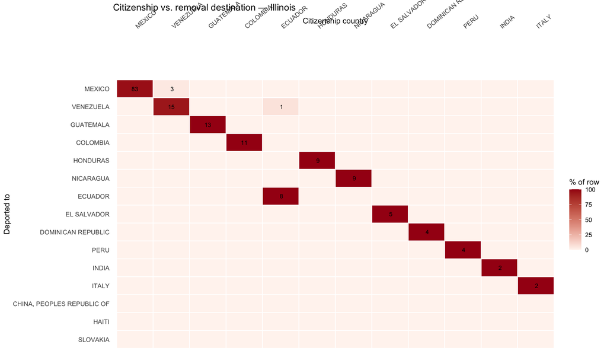

**Summary table:**

Removal destinations for Illinois arrests

| Country | N | % |
| --- | --- | --- |
| MEXICO | 86 | 50.0 |
| VENEZUELA | 16 | 9.3 |
| GUATEMALA | 13 | 7.6 |
| COLOMBIA | 11 | 6.4 |
| HONDURAS | 9 | 5.2 |
| NICARAGUA | 9 | 5.2 |
| ECUADOR | 8 | 4.7 |
| EL SALVADOR | 5 | 2.9 |
| DOMINICAN REPUBLIC | 4 | 2.3 |
| PERU | 4 | 2.3 |
| INDIA | 2 | 1.2 |
| ITALY | 2 | 1.2 |
| CHINA, PEOPLES REPUBLIC OF | 1 | 0.6 |
| HAITI | 1 | 0.6 |
| SLOVAKIA | 1 | 0.6 |

## Minor Detainees (Under 18)

**71 arrests** · **67 distinct individuals** · **15 detention stays.** Age is estimated as year(arrest) − birth year and may be off by up to one year.

| Metric | Value |
| --- | --- |
| Arrests of minors | 71 |
| Distinct minors | 67 |
| Detention stays | 15 |

**Age at arrest**

| Age | N |
| --- | --- |
| 4 | 4 |
| 5 | 6 |
| 6 | 8 |
| 7 | 6 |
| 8 | 6 |
| 9 | 6 |
| 10 | 2 |
| 11 | 5 |
| 12 | 8 |
| 13 | 3 |
| 14 | 2 |
| 15 | 6 |
| 16 | 7 |
| 17 | 2 |

**Nationality**

| Country | N | % |
| --- | --- | --- |
| ECUADOR | 20 | 28.2 |
| COLOMBIA | 18 | 25.4 |
| VENEZUELA | 16 | 22.5 |
| NICARAGUA | 5 | 7.0 |
| PERU | 5 | 7.0 |
| RUSSIA | 3 | 4.2 |
| MEXICO | 2 | 2.8 |
| INDIA | 1 | 1.4 |
| NIGERIA | 1 | 1.4 |

**First detention facility**

| DETLOC | Facility | N | % |
| --- | --- | --- | --- |
| CHIHOLD | CHICAGO HOLD ROOM | 14 | 93.3 |
| BSAHOLD | BROADVIEW SERVICE STAGING | 1 | 6.7 |

**Last detention facility**

| DETLOC | Facility | N | % |
| --- | --- | --- | --- |
| CHIHOLD | CHICAGO HOLD ROOM | 11 | 73.3 |
| STFRCTX | SOUTH TEXAS FAM RESIDENTIAL CENTER | 4 | 26.7 |

**Outcomes**

| Release reason | N | % |
| --- | --- | --- |
| Voluntary departure | 7 | 46.7 |
| Removed | 5 | 33.3 |
| NA | 3 | 20.0 |

## Data notes

- Source: [Deportation Data Project](https://deportationdata.org), FOIA 2026-ICLI-00005.
- Filtered to `apprehension_state == "ILLINOIS"` and `apprehension_date >= 2026-01-01`. Duplicate-flagged rows excluded.
- Stays linked via `unique_identifier`; only stays beginning on or after 2026-01-01 are included.
- Transfer flows show consecutive facility pairs from `detention_facility_codes_all`; min threshold = 5 transfers.
- County choropleth coverage: 13% of arrests mapped to a county.
- `stay_release_reason` is NA for stays open as of March 2026 (shown as “Pending / Unknown”).
- EROFCB = ERO El Paso Camp East Montana (militarized facility in Montana operated by El Paso ERO).